# Culex colorimetry analysis

Helle Aronson - Clément Vinauger

2026-06-19

**Foreword:** This notebook contains the R script required to produce the PCA plot (and associated statistical analyses) presented in figure 5 of Gregory *et al.*, Stage-specific divergence in larval thermal tolerance among populations of the *Culex pipiens* Assemblage. Journal of Medical Entomology, accepted for publication on June 18, 2026.

Execution of the code requires the raw data contained in the file: “Culex_Colorimetry_Data - Gregory et al 2026.xlsx”

### Loading required packages

```r
# If needed set the working directory to the folder where the notebook and data file are saved.
#setwd(dirname(rstudioapi::getActiveDocumentContext()$path))

library(tidyverse)
library(readxl)
library(lme4)
library(emmeans)
library(ggfortify)
library(ggbiplot)
library(dplyr)
```

### Import the merged dataset for GLM and multivariate analyses

```r
All_data <- readxl::read_xlsx("Culex_Colorimetry_Data - Gregory et al 2026.xlsx")
All_data$Individuals <- as.factor(seq(1:nrow(All_data)))
```

### Define the color scheme

```r
color.FL_MD <- "#DC9F1F"
color.ILAG_MD <- "#6FB4E7"
color.ILBG_MD <- "#C27CA6"
color.ME_MD <- "#3373B0"
color.TX_MD <- "#ECE24E"

color_order<- c("#DC9F1F","#6FB4E7", "#C27CA6", "#3373B0","#ECE24E")
```

## PCA analysis

```r
All_data %>% select(Protein:Triglyceride, Individuals, Population,) %>%
  drop_na() -> pca_data

pca_data %>% mutate(
  Food = as.factor(case_when(
    grepl("FT1", Population) ~ "MD"))) -> pca_data

pca_data %>% filter(Food == 'MD') -> pca_MD

MD_pca_results <- prcomp(pca_MD[,1:4])
summary(MD_pca_results)
```

```
## Importance of components:
##                           PC1    PC2    PC3     PC4
## Standard deviation     0.8428 0.4317 0.3454 0.15711
## Proportion of Variance 0.6826 0.1791 0.1146 0.02372
## Cumulative Proportion  0.6826 0.8617 0.9763 1.00000
```

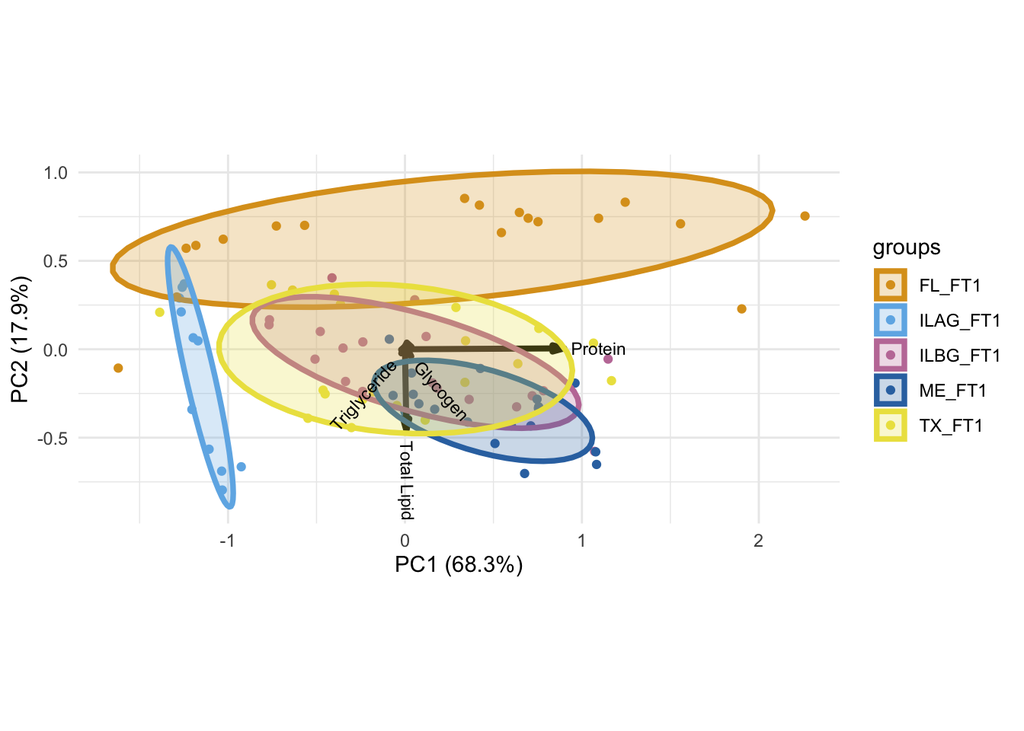

```r
ggbiplot(MD_pca_results, obs.scale = 1, var.scale = 1,
              groups = pca_MD$Population, ellipse = T) +
        scale_color_manual(values = color_order[seq(1,length(color_order))]) +
      scale_fill_manual(values = color_order[seq(1,length(color_order))]) +
  theme_minimal()
```

**Summary**: PC1 explains 68.26% of the variance and PC2 17.91% of the variance. Together, they explain 86.17% of the variance. Effects along PC1 are mostly driven by protein content and effects along PC2 by Total lipids.

*Note*:The separation between state-populations appears to be driven by lipid/triglyceride content but the separation between above and below ground forms seems to be driven by the protein content. Also, note a good amount of overlap between the Texas, Maine, and Below Ground populations.

## Generalized Linear Models

### Data preparation

```r
All_data_longer <- All_data %>% pivot_longer(!c(Population, ID, Individuals),
                                             names_to = "Nutrients",
                                             values_to = "Concentration") %>%
                  mutate(
  Food = case_when(
    grepl("FT1", Population) ~ "MD")) %>%
  mutate(
    Region_of_Origin = case_when(
      grepl("FL", Population) ~ "FL",
      grepl("ME", Population) ~ "ME",
      grepl("AG", Population) ~ "AG",
      grepl("BG", Population) ~ "BG",
      grepl("TX", Population) ~ "TX"))
```

### Global Model selection

First, comparison between additive and interactive models for an analysis that includes *all* the data.

```r
model_no_interaction <- glm(Concentration~Region_of_Origin+Nutrients, data= All_data_longer)
model_interactions <- glm(Concentration~Region_of_Origin*Nutrients, data= All_data_longer)

anova(model_no_interaction, model_interactions, test="LRT")
```

|  | Resid. Df | Resid. Dev | Df | Deviance | Pr(>Chi) |
| --- | --- | --- | --- | --- | --- |
| 1 | 379 | 84.79035 | NA | NA | NA |
| 2 | 367 | 53.65704 | 12 | 31.13331 | 6.879327e-39 |

### Model summary and *post-hoc* pairwise comparisons

```r
All_data_longer %>% filter(Food == 'MD') -> MD_data_longer
model_MD_food <- glm(Concentration~Region_of_Origin*Nutrients, data= MD_data_longer)
summary(model_MD_food)
```

```
##
## Call:
## glm(formula = Concentration ~ Region_of_Origin * Nutrients, data = MD_data_longer)
##
## Coefficients:
##                                          Estimate Std. Error t value Pr(>|t|)
## (Intercept)                               0.41879    0.08772   4.774 2.61e-06
## Region_of_OriginBG                        0.01047    0.12406   0.084   0.9328
## Region_of_OriginFL                        0.18984    0.12406   1.530   0.1268
## Region_of_OriginME                        0.10151    0.12250   0.829   0.4078
## Region_of_OriginTX                        0.80926    0.12250   6.606 1.39e-10
## NutrientsProtein                          0.08638    0.14099   0.613   0.5405
## NutrientsTotal Lipid                      0.64061    0.12250   5.230 2.86e-07
## NutrientsTriglyceride                     0.06121    0.12406   0.493   0.6220
## Region_of_OriginBG:NutrientsProtein       1.22646    0.18677   6.567 1.76e-10
## Region_of_OriginFL:NutrientsProtein       1.16068    0.18780   6.180 1.70e-09
## Region_of_OriginME:NutrientsProtein       1.50257    0.18574   8.090 8.84e-15
## Region_of_OriginTX:NutrientsProtein       0.27467    0.18574   1.479   0.1400
## Region_of_OriginBG:NutrientsTotal Lipid   0.11183    0.17324   0.646   0.5190
## Region_of_OriginFL:NutrientsTotal Lipid  -0.76179    0.17324  -4.397 1.44e-05
## Region_of_OriginME:NutrientsTotal Lipid   0.29829    0.17212   1.733   0.0839
## Region_of_OriginTX:NutrientsTotal Lipid  -0.77936    0.17212  -4.528 8.06e-06
## Region_of_OriginBG:NutrientsTriglyceride  0.08533    0.17434   0.489   0.6248
## Region_of_OriginFL:NutrientsTriglyceride -0.17384    0.17434  -0.997   0.3194
## Region_of_OriginME:NutrientsTriglyceride -0.19201    0.17324  -1.108   0.2684
## Region_of_OriginTX:NutrientsTriglyceride -0.78686    0.17324  -4.542 7.56e-06
##
## (Intercept)                              ***
## Region_of_OriginBG
## Region_of_OriginFL
## Region_of_OriginME
## Region_of_OriginTX                       ***
## NutrientsProtein
## NutrientsTotal Lipid                     ***
## NutrientsTriglyceride
## Region_of_OriginBG:NutrientsProtein      ***
## Region_of_OriginFL:NutrientsProtein      ***
## Region_of_OriginME:NutrientsProtein      ***
## Region_of_OriginTX:NutrientsProtein
## Region_of_OriginBG:NutrientsTotal Lipid
## Region_of_OriginFL:NutrientsTotal Lipid  ***
## Region_of_OriginME:NutrientsTotal Lipid  .
## Region_of_OriginTX:NutrientsTotal Lipid  ***
## Region_of_OriginBG:NutrientsTriglyceride
## Region_of_OriginFL:NutrientsTriglyceride
## Region_of_OriginME:NutrientsTriglyceride
## Region_of_OriginTX:NutrientsTriglyceride ***
## ---
## Signif. codes:  0 '***' 0.001 '**' 0.01 '*' 0.05 '.' 0.1 ' ' 1
##
## (Dispersion parameter for gaussian family taken to be 0.1462045)
##
##     Null deviance: 169.752  on 386  degrees of freedom
## Residual deviance:  53.657  on 367  degrees of freedom
##   (13 observations deleted due to missingness)
## AIC: 375.62
##
## Number of Fisher Scoring iterations: 2
```

**Summary:**

- The AG and TX origins are significant predictors of the nutrient content.
- Only lipids seem to significantly inform differences between populations.
- The interactions between specific nutrients and regions of origin are also significant predictors.

**Note:** Pairwise comparisons can be run to inform on specific contrasts. For readability, the code below subsets only the pairwise comparisons that are significant. Any pairwise comparison not listed can be assumed as non significant. The exact p-values for non-significant comparisons can be found in the object *emmMD*.

```r
emmMD <- emmeans(model_MD_food, pairwise~Nutrients*Region_of_Origin)
pairs_emmMD <- emmMD$contrasts
significant_contrastsMD <- as.data.frame(pairs_emmMD) |> subset(p.value < 0.05)
significant_contrastsMD
```

|  | contrast | estimate | SE | df | t.ratio | p.value |
| --- | --- | --- | --- | --- | --- | --- |
| 2 | Glycogen AG - Total Lipid AG | -0.6406105 | 0.1224957 | 367 | -5.229658 | 5.196305e-05 |
| 5 | Glycogen AG - Protein BG | -1.3233105 | 0.1224957 | 367 | -10.802915 | 0.000000e+00 |
| 6 | Glycogen AG - Total Lipid BG | -0.7629105 | 0.1224957 | 367 | -6.228060 | 2.436097e-07 |
| 9 | Glycogen AG - Protein FL | -1.4368947 | 0.1240562 | 367 | -11.582610 | 0.000000e+00 |
| 13 | Glycogen AG - Protein ME | -1.6904605 | 0.1224957 | 367 | -13.800163 | 0.000000e+00 |
| 14 | Glycogen AG - Total Lipid ME | -1.0404105 | 0.1224957 | 367 | -8.493446 | 0.000000e+00 |
| 16 | Glycogen AG - Glycogen TX | -0.8092605 | 0.1224957 | 367 | -6.606441 | 2.620885e-08 |
| 17 | Glycogen AG - Protein TX | -1.1703105 | 0.1224957 | 367 | -9.553891 | 0.000000e+00 |
| 18 | Glycogen AG - Total Lipid TX | -0.6705105 | 0.1224957 | 367 | -5.473748 | 1.507840e-05 |
| 20 | Protein AG - Total Lipid AG | -0.5542333 | 0.1396207 | 367 | -3.969565 | 1.268546e-02 |

[output cut: 105 more lines]

```r
NS_contrastsMD <- as.data.frame(pairs_emmMD) |> subset(p.value > 0.05)
NS_contrastsMD
```

|  | contrast | estimate | SE | df | t.ratio | p.value |
| --- | --- | --- | --- | --- | --- | --- |
| 1 | Glycogen AG - Protein AG | -0.086377193 | 0.1409918 | 367 | -0.61264001 | 1.00000000 |
| 3 | Glycogen AG - Triglyceride AG | -0.061210526 | 0.1240562 | 367 | -0.49340962 | 1.00000000 |
| 4 | Glycogen AG - Glycogen BG | -0.010473684 | 0.1240562 | 367 | -0.08442692 | 1.00000000 |
| 7 | Glycogen AG - Triglyceride BG | -0.157010526 | 0.1224957 | 367 | -1.28176367 | 0.99930548 |
| 8 | Glycogen AG - Glycogen FL | -0.189842105 | 0.1240562 | 367 | -1.53029105 | 0.99329846 |
| 10 | Glycogen AG - Total Lipid FL | -0.068660526 | 0.1224957 | 367 | -0.56051381 | 1.00000000 |
| 11 | Glycogen AG - Triglyceride FL | -0.077210526 | 0.1224957 | 367 | -0.63031218 | 0.99999999 |
| 12 | Glycogen AG - Glycogen ME | -0.101510526 | 0.1224957 | 367 | -0.82868651 | 0.99999913 |
| 15 | Glycogen AG - Triglyceride ME | 0.029289474 | 0.1224957 | 367 | 0.23910616 | 1.00000000 |
| 19 | Glycogen AG - Triglyceride TX | -0.083610526 | 0.1224957 | 367 | -0.68255892 | 0.99999997 |

[output cut: 65 more lines]

### Stacked bar plots

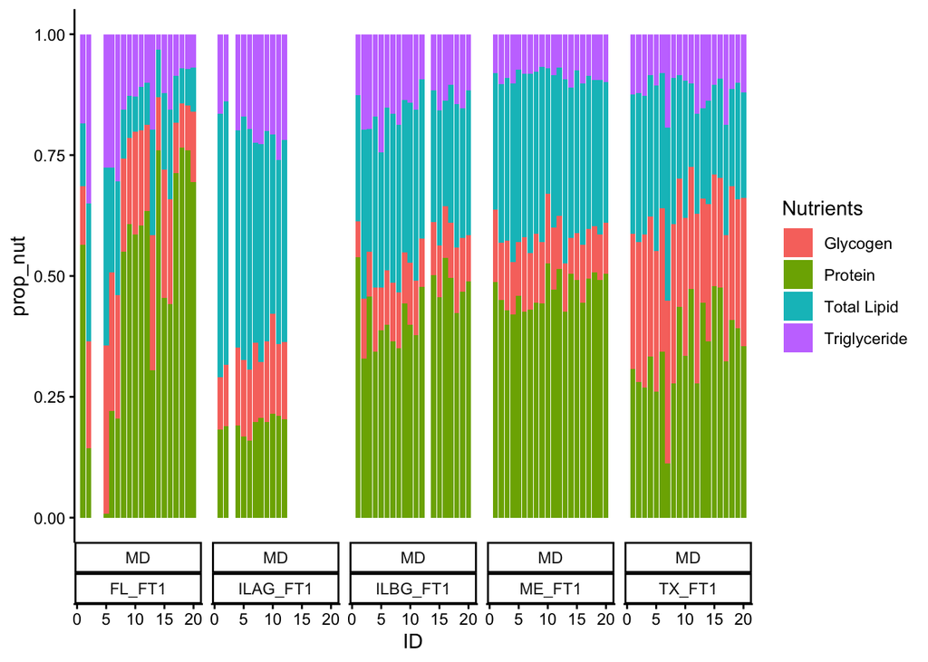

```r
All_data_longer %>% group_by(Population, Individuals) %>%
  mutate(sum_nut = sum(Concentration)) %>%
  mutate(prop_nut = Concentration/sum_nut) %>%
  mutate(sum_check = sum(prop_nut)) -> All_data_stacks
All_data_stacks$Individuals <- as.factor(All_data_stacks$Individuals)

ggplot(All_data_stacks, aes(x = ID, y= prop_nut, group = Population, fill = Nutrients)) +
    geom_bar(position = "stack", stat = 'identity') + theme_classic() + facet_grid(~Food*Population, switch = "x")
```